# Using Fingertips data in R

## Introduction

This document walks through how to use the [FingertipsR](https://github.com/ropensci/fingertipsR) and [FingertipsCharts](https://github.com/ukhsa-collaboration/fingertipscharts) packages in R.

Firstly, you must install fingertipsR as so:

```r
remotes::install_github("rOpenSci/fingertipsR",
                        build_vignettes = TRUE,
                        dependencies = "suggests")
```

You must also install Fingertipscharts as so:

```r
remotes::install_github("ukhsa-collaboration/fingertipscharts",
                        build_vignettes = TRUE)
```

The ‘Inidicator IDs’ and ‘Area Types’ tabs show the lists of indicator names and corresponding IDs and area type names and IDs.

NB: for counties/UAs you should use: **402 Upper tier local authorities (4/21-3/23)**. This is because the new areas do not have mappings to regions.

```r
library(fingertipsR)

indicator_id <- 219
df <- fingertips_data(IndicatorID = indicator_id, AreaTypeID = 402)

head(df)
```

|  | IndicatorID | IndicatorName | ParentCode | ParentName | AreaCode | AreaName | AreaType | Sex | Age | CategoryType | Category | Timeperiod | Value | LowerCI95.0limit | UpperCI95.0limit | LowerCI99.8limit | UpperCI99.8limit | Count | Denominator | Valuenote | RecentTrend | ComparedtoEnglandvalueorpercentiles | ComparedtoRegions(statistical)valueorpercentiles | TimeperiodSortable | Newdata | Comparedtogoal | Timeperiodrange |
| --- | --- | --- | --- | --- | --- | --- | --- | --- | --- | --- | --- | --- | --- | --- | --- | --- | --- | --- | --- | --- | --- | --- | --- | --- | --- | --- | --- |
| 1 | 219 | Hypertension: QOF prevalence | NA | NA | E92000001 | England | England | Persons | All ages | NA | NA | 2009/10 | 13.35144 | 13.34244 | 13.36045 | NA | NA | 7321472 | 54836561 | NA | NA | Not compared | Not compared | 20090000 | NA | NA | 1y |
| 2 | 219 | Hypertension: QOF prevalence | E92000001 | England | E12000001 | North East region (statistical) | Regions (statistical) | Persons | All ages | NA | NA | 2009/10 | NA | NA | NA | NA | NA | NA | NA | NA | NA | Not compared | Not compared | 20090000 | NA | NA | 1y |
| 3 | 219 | Hypertension: QOF prevalence | E92000001 | England | E12000002 | North West region (statistical) | Regions (statistical) | Persons | All ages | NA | NA | 2009/10 | NA | NA | NA | NA | NA | NA | NA | NA | NA | Not compared | Not compared | 20090000 | NA | NA | 1y |
| 4 | 219 | Hypertension: QOF prevalence | E92000001 | England | E12000003 | Yorkshire and the Humber region (statistical) | Regions (statistical) | Persons | All ages | NA | NA | 2009/10 | NA | NA | NA | NA | NA | NA | NA | NA | NA | Not compared | Not compared | 20090000 | NA | NA | 1y |
| 5 | 219 | Hypertension: QOF prevalence | E92000001 | England | E12000004 | East Midlands region (statistical) | Regions (statistical) | Persons | All ages | NA | NA | 2009/10 | NA | NA | NA | NA | NA | NA | NA | NA | NA | Not compared | Not compared | 20090000 | NA | NA | 1y |
| 6 | 219 | Hypertension: QOF prevalence | E92000001 | England | E12000005 | West Midlands region (statistical) | Regions (statistical) | Persons | All ages | NA | NA | 2009/10 | NA | NA | NA | NA | NA | NA | NA | NA | NA | Not compared | Not compared | 20090000 | NA | NA | 1y |

## Indicator IDs

When using the function on the first tab, you must pass in IndicatorID (NB you can pass in multiple indicator IDs as a list).

All metrics in Fingertips have a corresponding ID. This can be found on the description page for each indicator e.g. https://fingertips.phe.org.uk/profile/mortality-profile/data#page/6/gid/1938133009/pat/159/par/K02000001/ati/15/are/E92000001/iid/93823/age/1/sex/4/cat/-1/ctp/-1/yrr/1/cid/4/tbm/1

The below table gives a list of indicators and their corresponding IDs. You can use the search bar in the table to search for keywords to find relevant indicators.

| IndicatorID | IndicatorName |
| --- | --- |
| 108 | Under 75 mortality rate from all causes |
| 113 | Smoking attributable mortality (old method) |
| 114 | QOF Total List Size |
| 200 | Learning disability: QOF prevalence |
| 212 | Stroke: QOF prevalence |
| 219 | Hypertension: QOF prevalence |
| 224 | Epilepsy: QOF prevalence |
| 241 | Diabetes: QOF prevalence |
| 247 | Dementia: QOF prevalence |
| 253 | COPD: QOF prevalence |

[output cut: 1583 more lines]

## Area Types

The below table shows the possible area types for each indicator. Use the search function to identify the relevant area types for the indicator you are interested in.

NB: for counties/UAs you should use: **402 Upper tier local authorities (4/21-3/23)**. This is because the new areas do not have mappings to regions.

| IndicatorID | AreaTypeID | AreaTypeName |
| --- | --- | --- |
| 108 | 502 | Upper tier local authorities (post 4/23) |
| 108 | 501 | Lower tier local authorities (post 4/23) |
| 108 | 302 | Upper tier local authorities (4/20-3/21) |
| 108 | 301 | Lower tier local authorities (4/20-3/21) |
| 108 | 223 | NHS regions (44 + 45) |
| 108 | 221 | ICBs, former STPs |
| 108 | 15 | England |
| 108 | 6 | Government Office Region (E12) |
| 113 | 15 | England |
| 114 | 221 | ICBs, former STPs |

[output cut: 7854 more lines]

## Population Charts

This tab shows how to build a population pyramid. This code can be used for any county/UA by changing the region and areaname inputs.

The list below shows different options of counties/UAs by region.

NB: for counties/UAs you should use: **402 Upper tier local authorities (4/21-3/23)**. This is because the new areas do not have mappings to regions.

#### List of counties/UAs by Region

##### East Midlands region

| Area.Name |
| --- |
| Derby |
| Leicester |
| Rutland |
| Nottingham |
| North Northamptonshire |
| West Northamptonshire |
| Derbyshire |
| Leicestershire |
| Lincolnshire |
| Nottinghamshire |

##### East of England region

| Area.Name |
| --- |
| Peterborough |
| Luton |
| Southend-on-Sea |
| Thurrock |
| Bedford |
| Central Bedfordshire |
| Cambridgeshire |
| Essex |
| Hertfordshire |
| Norfolk |
| Suffolk |

##### London region

| Area.Name |
| --- |
| City of London |
| Barking and Dagenham |
| Barnet |
| Bexley |
| Brent |
| Bromley |
| Camden |
| Croydon |
| Ealing |
| Enfield |
| Greenwich |
| Hackney |
| Hammersmith and Fulham |
| Haringey |
| Harrow |
| Havering |
| Hillingdon |
| Hounslow |
| Islington |
| Kensington and Chelsea |
| Kingston upon Thames |
| Lambeth |
| Lewisham |
| Merton |
| Newham |
| Redbridge |
| Richmond upon Thames |
| Southwark |
| Sutton |
| Tower Hamlets |
| Waltham Forest |
| Wandsworth |
| Westminster |

##### North East region

| Area.Name |
| --- |
| Hartlepool |
| Middlesbrough |
| Redcar and Cleveland |
| Stockton-on-Tees |
| Darlington |
| County Durham |
| Northumberland |
| Newcastle upon Tyne |
| North Tyneside |
| South Tyneside |
| Sunderland |
| Gateshead |

##### North West region

| Area.Name |
| --- |
| Halton |
| Warrington |
| Blackburn with Darwen |
| Blackpool |
| Cheshire East |
| Cheshire West and Chester |
| Bolton |
| Bury |
| Manchester |
| Oldham |
| Rochdale |
| Salford |
| Stockport |
| Tameside |
| Trafford |
| Wigan |
| Knowsley |
| Liverpool |
| St. Helens |
| Sefton |
| Wirral |
| Lancashire |

##### South East region

| Area.Name |
| --- |
| Medway |
| Bracknell Forest |
| West Berkshire |
| Reading |
| Slough |
| Windsor and Maidenhead |
| Wokingham |
| Milton Keynes |
| Brighton and Hove |
| Portsmouth |
| Southampton |
| Isle of Wight |
| Buckinghamshire UA |
| East Sussex |
| Hampshire |
| Kent |
| Oxfordshire |
| Surrey |
| West Sussex |

##### South West region

| Area.Name |
| --- |
| Bath and North East Somerset |
| Bristol |
| North Somerset |
| South Gloucestershire |
| Plymouth |
| Torbay |
| Swindon |
| Cornwall |
| Isles of Scilly |
| Wiltshire |
| Bournemouth, Christchurch and Poole |
| Dorset |
| Devon |
| Gloucestershire |

##### West Midlands region

| Area.Name |
| --- |
| Herefordshire |
| Telford and Wrekin |
| Stoke-on-Trent |
| Shropshire |
| Birmingham |
| Coventry |
| Dudley |
| Sandwell |
| Solihull |
| Walsall |
| Wolverhampton |
| Staffordshire |
| Warwickshire |
| Worcestershire |

##### Yorkshire and the Humber region

| Area.Name |
| --- |
| Kingston upon Hull |
| East Riding of Yorkshire |
| North East Lincolnshire |
| North Lincolnshire |
| York |
| Barnsley |
| Doncaster |
| Rotherham |
| Sheffield |
| Bradford |
| Calderdale |
| Kirklees |
| Leeds |
| Wakefield |

### Population Chart

Here is the code you can use to build your population chart, inputting the area name and region from the above lists.

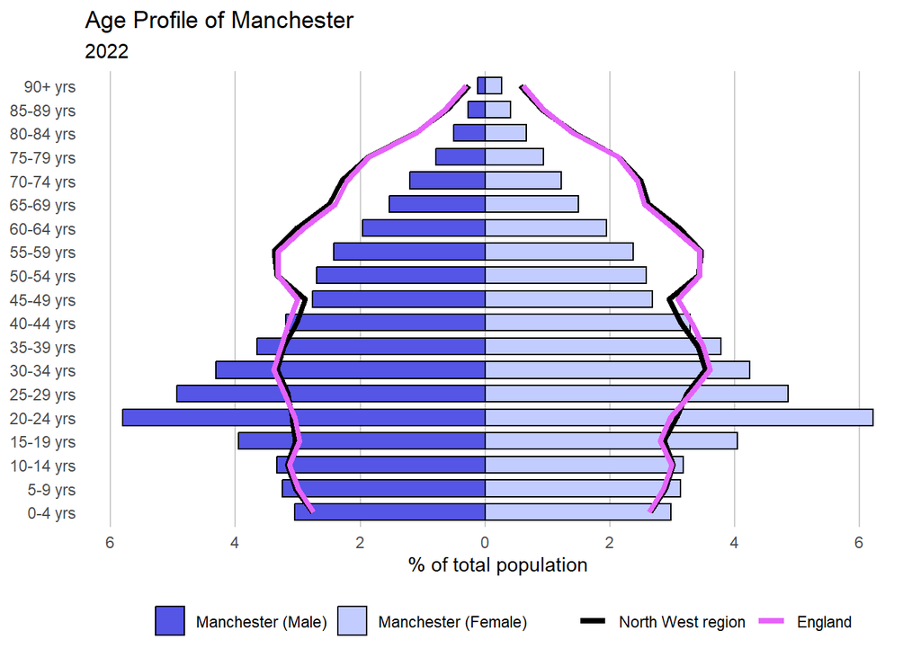

```r
library(dplyr)
library(fingertipsR)
library(forcats)
library(tidyverse)
library(fingertipscharts)


pop_data <- fingertips_data(IndicatorID = 92708,
                            AreaTypeID = 402)

#select area name (use table above to choose) and corresponding region. Region must be in this exact format e.g. "South East region" or "North West region"
region <- "North West region"
areaname <- "Manchester"
year = "2022"

pops <- pop_data %>%
  filter(Age != "All ages",
         Sex %in% c("Male", "Female"),
         Timeperiod == year,
         AreaName %in% c("England", areaname, paste(region,"(statistical)"))) %>%
  mutate(Age = factor(Age,
                      levels = c("0-4 yrs", "5-9 yrs", "10-14 yrs",
                                 "15-19 yrs", "20-24 yrs", "25-29 yrs",
                                 "30-34 yrs", "35-39 yrs", "40-44 yrs",
                                 "45-49 yrs", "50-54 yrs", "55-59 yrs",
                                 "60-64 yrs", "65-69 yrs", "70-74 yrs",
                                 "75-79 yrs", "80-84 yrs", "85-89 yrs",
                                 "90+ yrs"))) %>%
  mutate(AreaName = gsub(" \\(statistical\\)$", "", AreaName))


chart_title <- paste("Age Profile of", areaname)

p <- population(data = pops,
                value = Value,
                sex = Sex,
                age = Age,
                area = AreaName,
                area_name = areaname,
                comparator_1 = region,
                comparator_2 = "England",
                title = chart_title,
                subtitle = year,
                xlab = "% of total population")
p
```

## Comparing Areas

To determine the area types available, use the ‘Area Types’ tab. Once you have decided which area type to use, this bit of code will be able to identify areas within this type.

The most commonly used area types for our purposes will be **counties and UAs**, **ICBs** or **sub-ICBs** so the below gives you tables with area names for these options.

NB: for counties/UAs you should use: **402 Upper tier local authorities (4/21-3/23)**. This is because the new areas do not have mappings to regions.

### Area Names & Codes

#### Counties & UAs

|  | AreaCode | AreaName | ParentCode | Region |
| --- | --- | --- | --- | --- |
| 1 | E06000001 | Hartlepool | E12000001 | North East region |
| 2 | E06000002 | Middlesbrough | E12000001 | North East region |
| 3 | E06000003 | Redcar and Cleveland | E12000001 | North East region |
| 4 | E06000004 | Stockton-on-Tees | E12000001 | North East region |
| 5 | E06000005 | Darlington | E12000001 | North East region |
| 6 | E06000006 | Halton | E12000002 | North West region |
| 7 | E06000007 | Warrington | E12000002 | North West region |
| 8 | E06000008 | Blackburn with Darwen | E12000002 | North West region |
| 9 | E06000009 | Blackpool | E12000002 | North West region |
| 10 | E06000010 | Kingston upon Hull | E12000003 | Yorkshire and the Humber region |

[output cut: 142 more lines]

#### ICBs

|  | AreaCode | AreaName | ParentCode | Region |
| --- | --- | --- | --- | --- |
| 1 | nE54000008 | NHS Cheshire and Merseyside Integrated Care Board - QYG | E40000010 | North West NHS Region |
| 2 | nE54000010 | NHS Staffordshire and Stoke-on-Trent Integrated Care Board - QNC | E40000011 | Midlands NHS Region |
| 3 | nE54000011 | NHS Shropshire, Telford and Wrekin Integrated Care Board - QOC | E40000011 | Midlands NHS Region |
| 4 | nE54000013 | NHS Lincolnshire Integrated Care Board - QJM | E40000011 | Midlands NHS Region |
| 5 | nE54000015 | NHS Leicester, Leicestershire and Rutland Integrated Care Board - QK1 | E40000011 | Midlands NHS Region |
| 6 | nE54000018 | NHS Coventry and Warwickshire Integrated Care Board - QWU | E40000011 | Midlands NHS Region |
| 7 | nE54000019 | NHS Herefordshire and Worcestershire Integrated Care Board - QGH | E40000011 | Midlands NHS Region |
| 8 | nE54000022 | NHS Norfolk and Waveney Integrated Care Board - QMM | E40000007 | East of England NHS Region |
| 9 | nE54000023 | NHS Suffolk and North East Essex Integrated Care Board - QJG | E40000007 | East of England NHS Region |
| 10 | nE54000024 | NHS Bedfordshire, Luton and Milton Keynes Integrated Care Board - QHG | E40000007 | East of England NHS Region |

[output cut: 32 more lines]

#### Sub-ICBs

|  | AreaCode | AreaName | ParentCode | Region |
| --- | --- | --- | --- | --- |
| 1 | nE38000006 | South Yorkshire ICB - 02P | nE54000061 | NHS South Yorkshire Integrated Care Board - QF7 |
| 2 | nE38000007 | Mid and South Essex ICB - 99E | nE54000026 | NHS Mid and South Essex Integrated Care Board - QH8 |
| 3 | nE38000008 | Nottingham and Nottinghamshire ICB - 02Q | nE54000060 | NHS Nottingham and Nottinghamshire Integrated Care Board - QT1 |
| 4 | nE38000014 | Lancashire and South Cumbria ICB - 00Q | nE54000048 | NHS Lancashire and South Cumbria Integrated Care Board - QE1 |
| 5 | nE38000015 | Lancashire and South Cumbria ICB - 00R | nE54000048 | NHS Lancashire and South Cumbria Integrated Care Board - QE1 |
| 6 | nE38000016 | Greater Manchester ICB - 00T | nE54000057 | NHS Greater Manchester Integrated Care Board - QOP |
| 7 | nE38000021 | Sussex ICB - 09D | nE54000053 | NHS Sussex Integrated Care Board - QNX |
| 8 | nE38000024 | Greater Manchester ICB - 00V | nE54000057 | NHS Greater Manchester Integrated Care Board - QOP |
| 9 | nE38000025 | West Yorkshire ICB - 02T | nE54000054 | NHS West Yorkshire Integrated Care Board - QWO |
| 10 | nE38000028 | Staffordshire and Stoke-on-Trent ICB - 04Y | nE54000010 | NHS Staffordshire and Stoke-on-Trent Integrated Care Board - QNC |

[output cut: 96 more lines]

### Code for plot

In the below code, input the ParentCode of an area you wish to compare.

E.g. 1. if you want to compare how ‘Brent’ (the county/UA) performs against the other areas in it’s region: in the above table, search for ‘Brent’ in the Counties & UAs tab and copy the ParentCode ‘E12000007’.

E.g. 2. if you want to compare how the sub-ICB ‘Greater Manchester ICB - 01G’ performs against the other sub-ICBs in its ICB: in the above table, search for ‘Greater Manchester ICB - 01G’ in the Sub-ICB tab and copy the ParentCode ‘nE54000057’.

Run the code below to output the possible sexes and ages of your selected indicator which you need to use to decide what to filter by (if applicable, in some cases you will just have to use ‘Persons’ and ‘All Ages’).

```r
library(dplyr)
library(fingertipsR)
library(fingertipscharts)

# input relevant code into region and ID of the indicator
region <- "E12000006"
indicatorid <- 91102

if (startsWith(region, "nE54")) {
 areatype <- 66
} else if (startsWith(region, "E4")) {
  areatype <- 221
} else {
  areatype <- 402
}

top_names <- c("E92000001", region)
df <- fingertips_data(IndicatorID = indicatorid,
                      AreaTypeID = areatype) %>%
  filter(ParentCode == region |
           AreaCode %in% top_names)

df <- df %>%
  filter(TimeperiodSortable == max(TimeperiodSortable))

ordered_levels <- c("Better",
                    "Higher",
                    "Similar",
                    "Worse",
                    "Lower",
                    "Not compared")

if (startsWith(region, "nE54")) {
  df <- df %>%
    mutate(`ComparedtoICBsvalueorpercentiles` = ifelse(is.na(`ComparedtoICBsvalueorpercentiles`), `ComparedtoICBsvalueorpercentiles`, gsub(" 99.8", "", `ComparedtoICBsvalueorpercentiles`))) %>%
    mutate(`ComparedtoICBsvalueorpercentiles` =
           factor(`ComparedtoICBsvalueorpercentiles`,
                  levels = ordered_levels))
} else if (startsWith(region, "E4")) {
  df <- df %>%
    mutate(`ComparedtoNHSregions(sinceICBsetup)valueorpercentiles` = ifelse(is.na(`ComparedtoNHSregions(sinceICBsetup)valueorpercentiles`), `ComparedtoNHSregions(sinceICBsetup)valueorpercentiles`, gsub(" 99.8", "", `ComparedtoNHSregions(sinceICBsetup)valueorpercentiles`))) %>%
    mutate(`ComparedtoNHSregions(sinceICBsetup)valueorpercentiles` =
           factor(`ComparedtoNHSregions(sinceICBsetup)valueorpercentiles`,
                  levels = ordered_levels))
} else {
  df <- df %>%
    mutate(`ComparedtoRegions(statistical)valueorpercentiles` =
             factor(`ComparedtoRegions(statistical)valueorpercentiles`,
                    levels = ordered_levels))}

df_outputs <- df %>%
  distinct(AreaType, Sex, Age)

print(df_outputs)
```

```
##                           AreaType    Sex Age
## 1                          England   Male  65
## 2                          England Female  65
## 3            Regions (statistical)   Male  65
## 4            Regions (statistical) Female  65
## 5 Counties & UAs (2021/22-2022/23)   Male  65
## 6 Counties & UAs (2021/22-2022/23) Female  65
```

Using the filters you require, this code generates the chart.

NB is the only option is ‘Persons’ and ‘All Ages’ this **must still be inputted** as the sex and age variables.

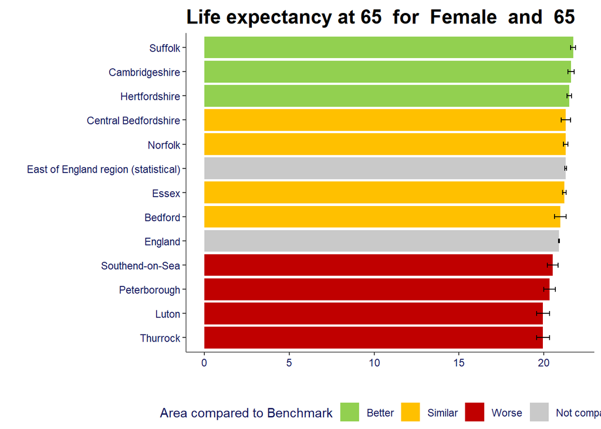

```r
#filter sex and age as per the above table
sex = "Female"
age = "65"

df <- df %>%
  filter(Age == age,
         Sex == sex)

df <- df %>%
  mutate(AreaName = factor(AreaName, levels = c(top_names, setdiff(unique(AreaName), top_names))))

if (startsWith(region, "nE54")) {
  p <- compare_areas(df,
                     AreaName,
                     Value,
                     fill = `ComparedtoICBsvalueorpercentiles`,
                     lowerci = LowerCI95.0limit,
                     upperci = UpperCI95.0limit,
                     order = "desc",
                     top_areas = top_names,
                     title = paste(unique(df$IndicatorName)," for ",sex," and ",age))
} else if (startsWith(region, "E4")) {
  p <- compare_areas(df,
                     AreaName,
                     Value,
                     fill = `ComparedtoNHSregions(sinceICBsetup)valueorpercentiles`,
                     lowerci = LowerCI95.0limit,
                     upperci = UpperCI95.0limit,
                     order = "desc",
                     top_areas = top_names,
                     title = paste(unique(df$IndicatorName)," for ",sex," and ",age))
} else {p <- compare_areas(df,
                           AreaName,
                           Value,
                           fill = `ComparedtoRegions(statistical)valueorpercentiles`,
                           lowerci = LowerCI95.0limit,
                           upperci = UpperCI95.0limit,
                           order = "desc",
                           top_areas = top_names,
                           title = paste(unique(df$IndicatorName)," for ",sex," and ",age))}
p
```

## Indicator Trends

To determine the area types available, use the ‘Area Types’ tab. Once you have decided which area type to use, this bit of code will be able to identify areas within this type.

The most commonly used area types for our purposes will be **counties and UAs**, **ICBs** or **sub-ICBs** so the below gives you tables with area names for these options.

NB: for counties/UAs you should use: **402 Upper tier local authorities (4/21-3/23)**. This is because the new areas do not have mappings to regions.

### Area Names & Codes

#### Counties & UAs

|  | AreaCode | AreaName | Region |
| --- | --- | --- | --- |
| 1 | E06000001 | Hartlepool | North East region |
| 2 | E06000002 | Middlesbrough | North East region |
| 3 | E06000003 | Redcar and Cleveland | North East region |
| 4 | E06000004 | Stockton-on-Tees | North East region |
| 5 | E06000005 | Darlington | North East region |
| 6 | E06000006 | Halton | North West region |
| 7 | E06000007 | Warrington | North West region |
| 8 | E06000008 | Blackburn with Darwen | North West region |
| 9 | E06000009 | Blackpool | North West region |
| 10 | E06000010 | Kingston upon Hull | Yorkshire and the Humber region |

[output cut: 142 more lines]

#### ICBs

|  | AreaCode | AreaName | Region |
| --- | --- | --- | --- |
| 1 | nE54000008 | NHS Cheshire and Merseyside Integrated Care Board - QYG | North West NHS Region |
| 2 | nE54000010 | NHS Staffordshire and Stoke-on-Trent Integrated Care Board - QNC | Midlands NHS Region |
| 3 | nE54000011 | NHS Shropshire, Telford and Wrekin Integrated Care Board - QOC | Midlands NHS Region |
| 4 | nE54000013 | NHS Lincolnshire Integrated Care Board - QJM | Midlands NHS Region |
| 5 | nE54000015 | NHS Leicester, Leicestershire and Rutland Integrated Care Board - QK1 | Midlands NHS Region |
| 6 | nE54000018 | NHS Coventry and Warwickshire Integrated Care Board - QWU | Midlands NHS Region |
| 7 | nE54000019 | NHS Herefordshire and Worcestershire Integrated Care Board - QGH | Midlands NHS Region |
| 8 | nE54000022 | NHS Norfolk and Waveney Integrated Care Board - QMM | East of England NHS Region |
| 9 | nE54000023 | NHS Suffolk and North East Essex Integrated Care Board - QJG | East of England NHS Region |
| 10 | nE54000024 | NHS Bedfordshire, Luton and Milton Keynes Integrated Care Board - QHG | East of England NHS Region |

[output cut: 32 more lines]

#### Sub-ICBs

|  | AreaCode | AreaName | Region |
| --- | --- | --- | --- |
| 1 | nE38000006 | South Yorkshire ICB - 02P | NHS South Yorkshire Integrated Care Board - QF7 |
| 2 | nE38000007 | Mid and South Essex ICB - 99E | NHS Mid and South Essex Integrated Care Board - QH8 |
| 3 | nE38000008 | Nottingham and Nottinghamshire ICB - 02Q | NHS Nottingham and Nottinghamshire Integrated Care Board - QT1 |
| 4 | nE38000014 | Lancashire and South Cumbria ICB - 00Q | NHS Lancashire and South Cumbria Integrated Care Board - QE1 |
| 5 | nE38000015 | Lancashire and South Cumbria ICB - 00R | NHS Lancashire and South Cumbria Integrated Care Board - QE1 |
| 6 | nE38000016 | Greater Manchester ICB - 00T | NHS Greater Manchester Integrated Care Board - QOP |
| 7 | nE38000021 | Sussex ICB - 09D | NHS Sussex Integrated Care Board - QNX |
| 8 | nE38000024 | Greater Manchester ICB - 00V | NHS Greater Manchester Integrated Care Board - QOP |
| 9 | nE38000025 | West Yorkshire ICB - 02T | NHS West Yorkshire Integrated Care Board - QWO |
| 10 | nE38000028 | Staffordshire and Stoke-on-Trent ICB - 04Y | NHS Staffordshire and Stoke-on-Trent Integrated Care Board - QNC |

[output cut: 96 more lines]

### Code for chart

From the above table, input the relevant areacode as the area variable.

Also decide in the inputs if you want to compare your area to England or its parent area. For counties/UAs, the parent is the region; for ICBs the parents is the NHS region and for sub-ICBs the parent is the ICB).

NB if you are looking at an ICB, the NHS region boundaries recently changed so it is advised to use England as the comparator.

Run the code below to output the possible sexes and ages of your selected indicator which you need to use to decide what to filter by (if applicable, in some cases you will just have to use ‘Persons’ and ‘All Ages’).

```r
library(fingertipsR)
library(dplyr)
library(tidyr)
library(ggplot2)

#input area code from table above; input indicator ID and input comparator (either England or Parent)
area <- c("nE54000008")
indicator <- 20601
comparator <- "England"

# do not change this code
if (startsWith(area, "nE38") & comparator == "Parent") {
  areatype <- 66
  parenttype <- 221
} else if (startsWith(area, "nE38") & comparator == "England") {
  areatype <- 66
  parenttype <- 15
} else if (startsWith(area, "nE54") & comparator == "Parent") {
  areatype <- 221
  parenttype <- 223
} else if (startsWith(area, "nE54") & comparator == "England") {
  areatype <- 221
  parenttype <- 15
} else {
  areatype <- 402
  parenttype <- 221
}

if (areatype == 402 & comparator == "England") {
  data_frame <- fingertips_data(IndicatorID = indicator,
                                AreaTypeID = areatype)
  data_frame <- data_frame %>%
    select(TimeperiodSortable,Value,AreaName,AreaCode,LowerCI95.0limit,UpperCI95.0limit,
           IndicatorName,Timeperiod,ParentName,ParentCode,Sex,Age) %>%
    filter(is.na(ParentCode) | AreaCode == area)
} else if (areatype == 402 & comparator == "Parent"){
  data_frame <- fingertips_data(IndicatorID = indicator,
                                AreaTypeID = areatype)
  data_frame <- data_frame %>%
    select(TimeperiodSortable,Value,AreaName,AreaCode,LowerCI95.0limit,UpperCI95.0limit,
           IndicatorName,Timeperiod,ParentName,ParentCode,Sex,Age)
  parent <- data_frame %>%
    filter(AreaCode == area) %>%
    select(ParentCode) %>%
    unique() %>%
    pull(ParentCode)
  data_frame <- data_frame %>%
    filter(AreaCode == parent | AreaCode == area)
} else if (comparator == "Parent") {
  data_frame_1 <- fingertips_data(IndicatorID = indicator,
                                  AreaTypeID = areatype,
                                  AreaCode = area)
  data_frame_1 <- data_frame_1 %>%
    select(TimeperiodSortable,Value,AreaName,AreaCode,LowerCI95.0limit,UpperCI95.0limit,
           IndicatorName,Timeperiod,ParentName,ParentCode,Sex,Age)
  parent <- data_frame_1 %>%
    select(ParentCode) %>%
    filter(!is.na(ParentCode)) %>%
    unique() %>%
    pull(ParentCode)
  data_frame_2 <- fingertips_data(IndicatorID = indicator,
                                  AreaTypeID = parenttype,
                                  AreaCode = parent)
  data_frame_2 <- data_frame_2 %>%
    select(TimeperiodSortable,Value,AreaName,AreaCode,LowerCI95.0limit,UpperCI95.0limit,
           IndicatorName,Timeperiod,ParentName,ParentCode,Sex,Age)
  data_frame <- bind_rows(data_frame_1,data_frame_2)
} else {
  data_frame_1 <- fingertips_data(IndicatorID = indicator,
                                  AreaTypeID = areatype,
                                  AreaCode = area)
  data_frame_1 <- data_frame_1 %>%
    select(TimeperiodSortable,Value,AreaName,AreaCode,LowerCI95.0limit,UpperCI95.0limit,
           IndicatorName,Timeperiod,ParentName,ParentCode,Sex,Age)
  data_frame_2 <- fingertips_data(IndicatorID = indicator,
                                  AreaTypeID = 15)
  data_frame_2 <- data_frame_2 %>%
    select(TimeperiodSortable,Value,AreaName,AreaCode,LowerCI95.0limit,UpperCI95.0limit,
           IndicatorName,Timeperiod,ParentName,ParentCode,Sex,Age)
  data_frame <- bind_rows(data_frame_1,data_frame_2)
}

data_frame_outputs <- data_frame %>%
  select(AreaName, Sex, Age) %>%
  distinct()

datatable(data_frame_outputs)
```

|  | AreaName | Sex | Age |
| --- | --- | --- | --- |
| 1 | NHS Cheshire and Merseyside Integrated Care Board - QYG | Persons | 4-5 yrs |
| 2 | England | Male | 4-5 yrs |
| 3 | England | Female | 4-5 yrs |
| 4 | England | Persons | 4-5 yrs |

Using the filters you require, this code generates the chart.

NB is the only option is ‘Persons’ and ‘All Ages’ this **must still be inputted** as the sex and age variables.

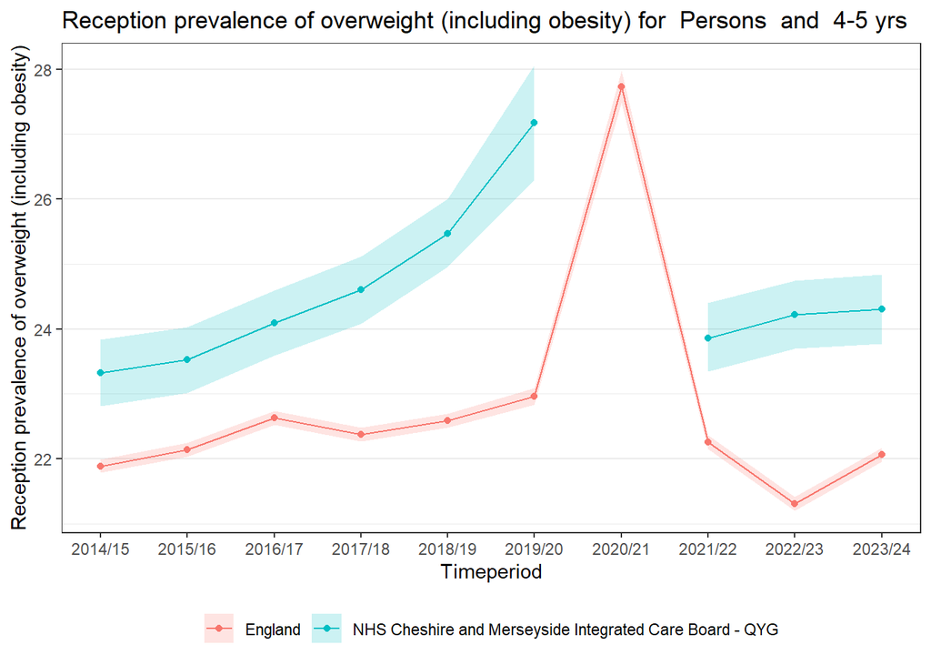

```r
#filter sex and age as per the above table
sex = "Persons"
age = "4-5 yrs"

data_frame <- data_frame %>%
  filter(Sex == sex) %>%
  filter(Age == age)

timeperiod_labels <- unique(data_frame$Timeperiod)

chart_title <- paste(unique(data_frame$IndicatorName),"for ",sex," and ",age)

area_data <- data_frame %>%
  filter(AreaCode == area)

area_min_year <- min(area_data$TimeperiodSortable)
area_data_min_year <- area_data %>%
  filter(TimeperiodSortable >= area_min_year)

min_value_row <- area_data_min_year[which.min(area_data_min_year$Value), ]
year_for_min_value <- min_value_row$TimeperiodSortable

data_frame <- data_frame %>%
  filter(TimeperiodSortable >= year_for_min_value)

#plot the trend
data_frame_chart <- data_frame %>%
  ggplot(aes(x = TimeperiodSortable, y = Value, colour = AreaName)) +
  geom_line() +
  geom_ribbon(aes(ymin = LowerCI95.0limit,
                  ymax = UpperCI95.0limit,
                  fill = AreaName),
              alpha = 0.2,
              colour = NA) +
  geom_point() +
  labs(y = unique(data_frame$IndicatorName),
       title = chart_title) +
  scale_color_discrete(name = data_frame$AreaType) +
  scale_fill_discrete(name = data_frame$AreaType) +
  theme_bw() +
  theme(axis.text.x = element_text(angle = 0),
        panel.grid.major.x = element_blank(),
        panel.grid.minor.x = element_blank(),
        legend.position = "bottom") +
  scale_x_continuous(name = "Timeperiod",
                     breaks = unique(data_frame$TimeperiodSortable),
                     labels = unique(data_frame$Timeperiod))

data_frame_chart
```

## Choropleths

The code below will produce choropleths for different indicators. The sex and age variables must be specified to filter the dataset appropriately.

Run the code below to output the possible sexes and ages of your selected indicator which you need to use to decide what to filter by (if applicable, in some cases you will just have to use ‘Persons’ and ‘All Ages’).

For choropleths, either use the counties/UAs or ICB area type. To determine which area type is applicable, use the Area Types tab. For counties/UAs you should use: **502 Upper tier local authorities (post Apr-23)** to align with the map rather than the pre April-23 counties/UAs.

```r
#input area type of 502 for counties/UAs or 221 for ICBs
area_type <- 502
indiator_id <- 40401

df <- fingertips_data(IndicatorID = indiator_id,
                      AreaTypeID = area_type) %>%
  filter(TimeperiodSortable == max(TimeperiodSortable))

df_outputs <- df %>%
  select(AreaType, Sex, Age) %>%
  distinct()

datatable(df_outputs)
```

|  | AreaType | Sex | Age |
| --- | --- | --- | --- |
| 1 | England | Male | &lt;75 yrs |
| 2 | England | Female | &lt;75 yrs |
| 3 | England | Persons | &lt;75 yrs |
| 4 | Counties &amp; UAs (from Apr 2023) | Male | &lt;75 yrs |
| 5 | Counties &amp; UAs (from Apr 2023) | Female | &lt;75 yrs |
| 6 | Counties &amp; UAs (from Apr 2023) | Persons | &lt;75 yrs |

Using the filters you require, this code generates the choropleth.

NB is the only option is ‘Persons’ and ‘All Ages’ this **must still be inputted** as the sex and age variables.

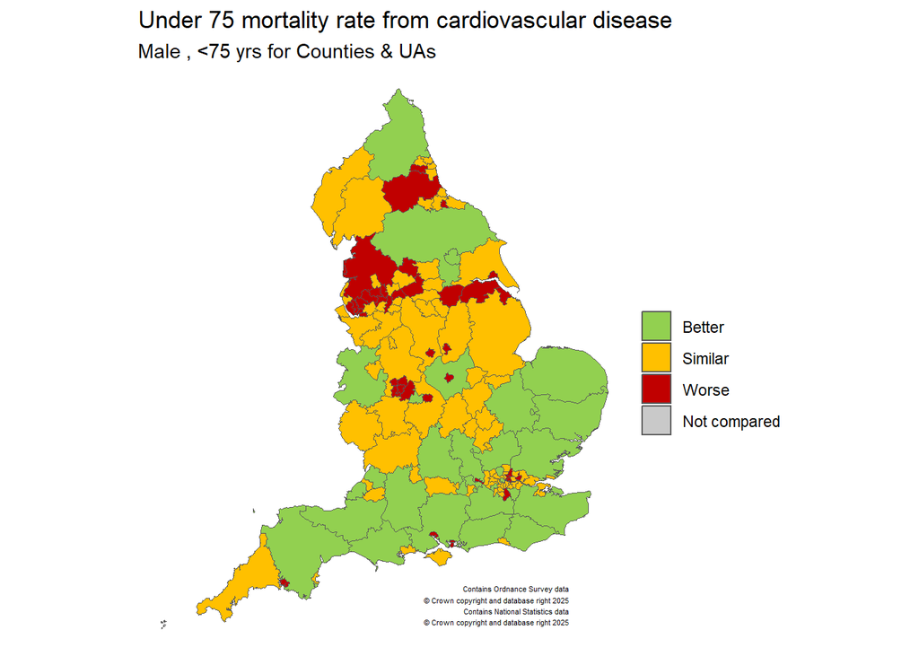

```r
#select Persons, Males or Females
sex <- "Male"
age <- "<75 yrs"

df <- df %>% filter(Sex == sex,
                    Age == age)

if (area_type == 221) {
  subtitle <- paste(sex, ",", age, "for Integrated Care Boards")
  ons_api <- "https://services1.arcgis.com/ESMARspQHYMw9BZ9/arcgis/rest/services/Integrated_Care_Boards_April_2023_EN_BSC/FeatureServer/0/query?outFields=*&where=1%3D1&f=geojson"
} else if (area_type == 502) {
  subtitle <- paste(sex, ",", age, "for Counties & UAs")
  ons_api <- "https://services1.arcgis.com/ESMARspQHYMw9BZ9/arcgis/rest/services/Counties_and_Unitary_Authorities_December_2023_Boundaries_UK_BUC/FeatureServer/0/query?outFields=*&where=1%3D1&f=geojson"
} else {
  }

ordered_levels <- c("Better",
                    "Higher",
                    "Similar",
                    "Worse",
                    "Lower",
                    "Not compared")

df <- df %>%
  mutate(ComparedtoEnglandvalueorpercentiles =
           factor(ComparedtoEnglandvalueorpercentiles,
                  levels = ordered_levels)) %>%
  mutate(AreaCode = sub("^n", "", AreaCode))

title <- df$IndicatorName

p <- fingertipscharts::map(data = df,
                           ons_api = ons_api,
                           area_code = AreaCode,
                           fill = ComparedtoEnglandvalueorpercentiles,
                           title = title,
                           subtitle = subtitle,
                           copyright_size = 1.5)
p
```